# High Frequency Trading

Joan Antoni Seguí Serra

# Problem Set 1

```r
library(data.table)
library(ggplot2)
library(reshape2)
library(kableExtra)
library(knitr)
options(knitr.table.format = "latex")
```

## EXERCISE 1

```r
rm(list = ls())
Stock1LOBLEV <- fread("C:/Users/Jt_an/Google Drive/GSE - Finance/2 trim_/HFT/Assignments/FIRST/Stock1LOBLEV.txt")
```

```r
Stock1LOBLEV<- Stock1LOBLEV[,.(date,time, sign, quote,vol = nHFTd + nHFTh + HFTd + HFTh)]
MP<-Stock1LOBLEV[sign==1 | sign==-1,.(midpoint =sum(quote)/2), by="date,time"]

Stock1LOBLEV<- Stock1LOBLEV[MP,on = c(date="date",time="time")]
```

- Relative bid-ask spread (spread divided by the quote midpoint)

```r
RS<- Stock1LOBLEV[sign==1,.(RS = abs(midpoint - quote)*2/midpoint*10000), by=.(date,time)]
```

- Log of the dollar depth at the best quotes (natural logarithm of ask_depth + bid_depth in US dollars)

```r
DepthBest <- Stock1LOBLEV[sign==1 | sign==-1,.(depth= log(sum(vol*quote))), by="date,time"]
```

- Log of the dollar depth at the 5 best quotes (natural logarithm of the accumulated depth at the best quotes in US dollars)

```r
DepthBest5 <- Stock1LOBLEV[between(sign,-5,5),.(depth= log(sum(vol*quote))), by="date,time"]
```

- Log of the dollar depth within 10 ticks from the quote midpoint (same as before, but limiting the computation to the depth posted at or less than 10 ticks from the quote midpoint; ignore the rest of the book)

```r
DepthBest10 <- Stock1LOBLEV[abs(midpoint - quote)<= 0.10,.(depth= log(sum(vol*quote))),by="date,time" ]
```

Next, for each metric, compute medians across days for each minute of the trading session. Generate a plot with the statistics obtained for each metric (Figure 1a to Figure 1d). On the vertical axis, you must have the median magnitude of the metric. On the horizontal axis, you must have the minute of the trading session. Discuss the regular intraday patterns obtained and its implications for the costs of trading.

```r
fig_1a <- DepthBest[,.(median = median(depth)), by="time"]
```

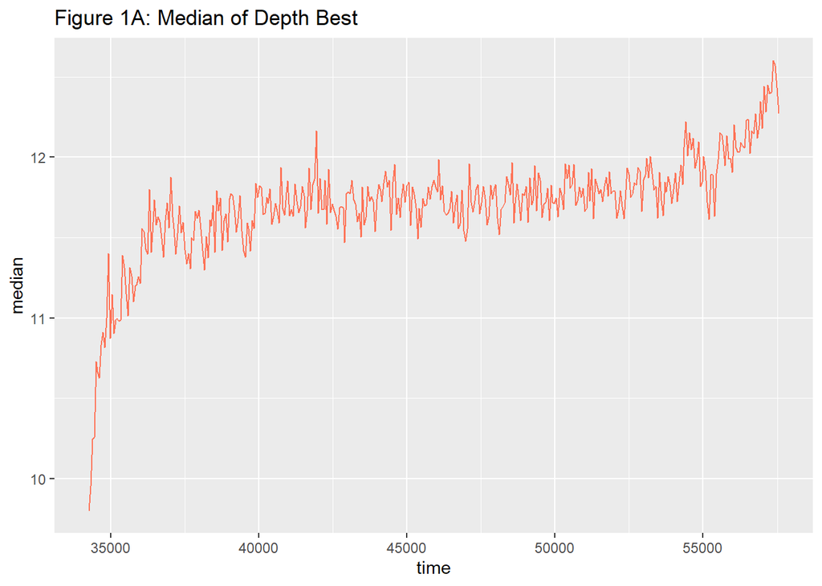

```r
ggplot(fig_1a, aes(time, median))+
  geom_line(colour="coral1")+
  ggtitle("Figure 1A: Median of Depth Best")
```

```r
fig_1b <- DepthBest5[,.(median = median(depth)), by="time"]
```

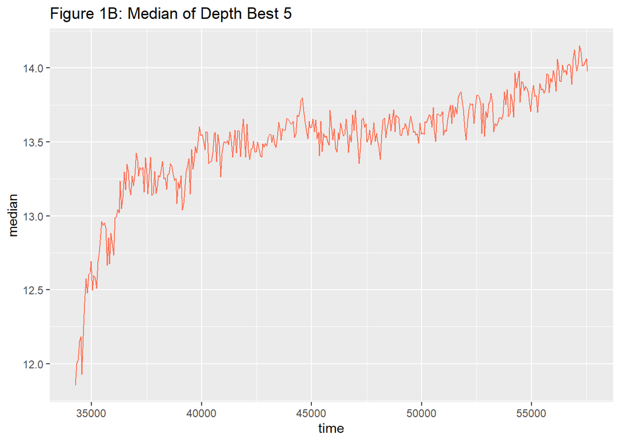

```r
ggplot(fig_1b, aes(time, median))+
  geom_line(colour="coral1")+
  ggtitle("Figure 1B: Median of Depth Best 5")
```

```r
fig_1c <- DepthBest10[,.(median = median(depth)), by="time"]
```

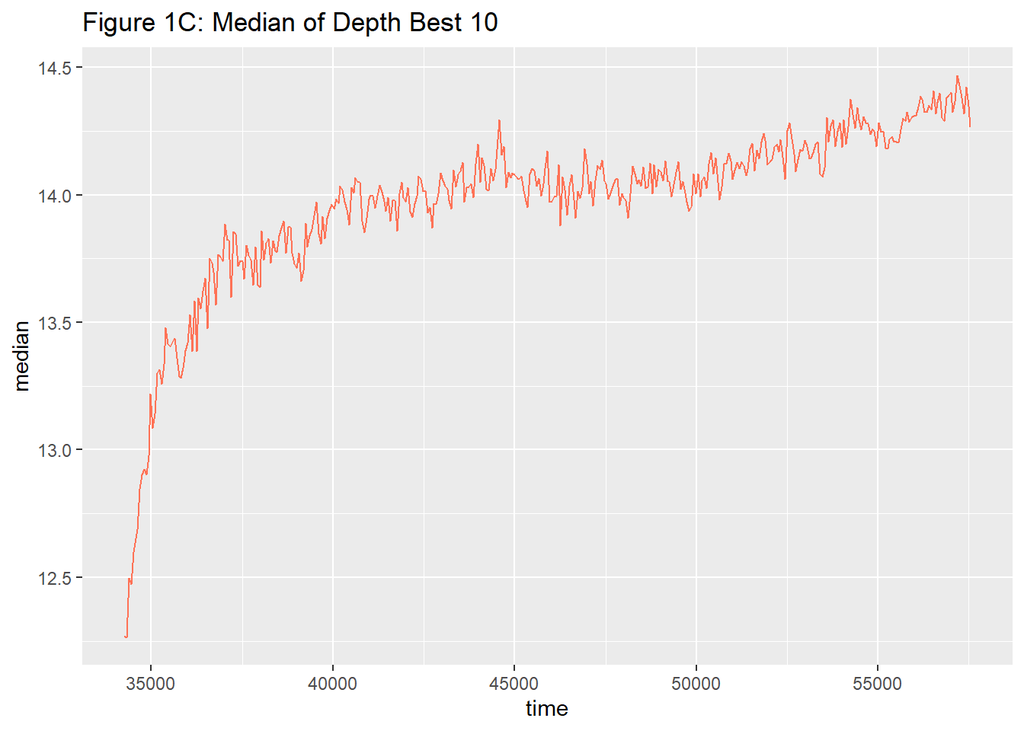

```r
ggplot(fig_1c, aes(time, median))+
  geom_line(colour="coral1")+
  ggtitle("Figure 1C: Median of Depth Best 10")
```

```r
fig_1d <- RS[,.(median = median(RS)), by="time"]
```

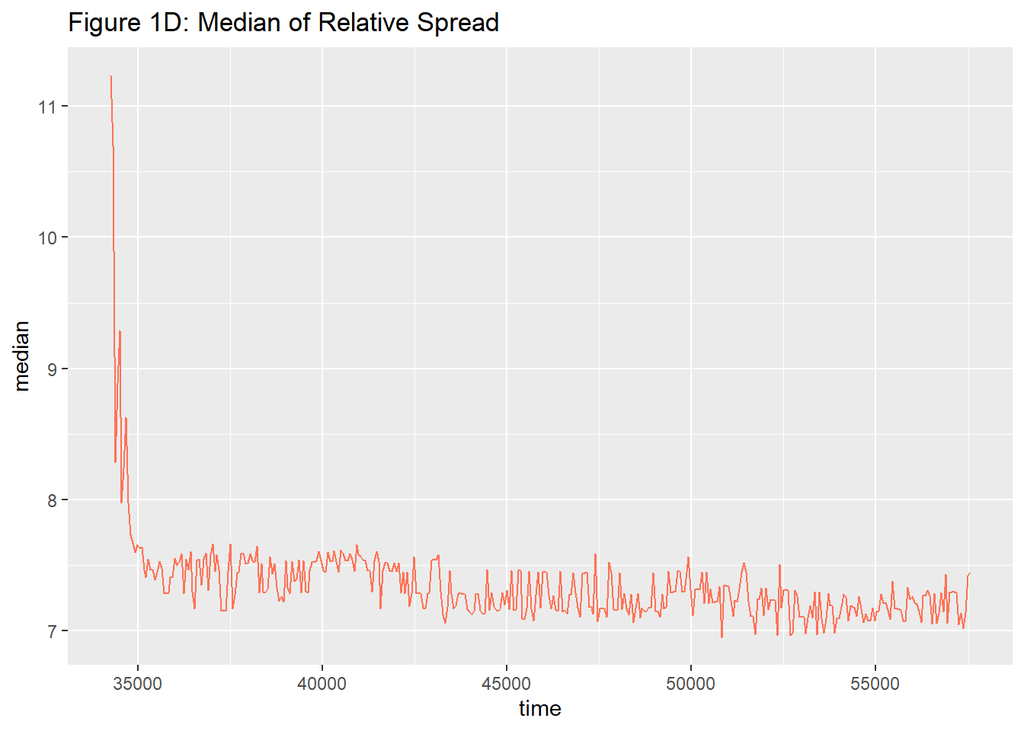

```r
ggplot(fig_1d, aes(time, median))+
  geom_line(colour="coral1")+
  ggtitle("Figure 1D: Median of Relative Spread")
```

Consider now RS and DepthTick10 only. Normalize the intraday regular patterns so that they have both mean zero and standard deviation 1. The plot both intraday patterns together into the same figure (Figure 2). What do you conclude about how liquidity providers manage regular variations in the risk of providing liquidity over the trading session?

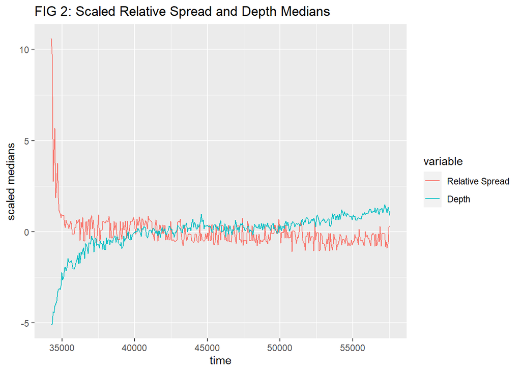

```r
RS_DT10 <- RS[DepthBest10,on = c(date="date",time="time")]
fig_2 <- RS_DT10[, .(RS=median(RS), depth=median(depth)), by="time"][, .(time,RS=scale(RS), depth=scale(depth))]
colnames(fig_2)=c("time", "Relative Spread", "Depth")
fig_2 <- melt(fig_2,id="time")

ggplot(fig_2, aes(time,value, colour=variable))+
  geom_line()+
  labs(y="scaled medians","time", title="FIG 2: Scaled Relative Spread and Depth Medians")
```

## EXERCISE 2

```r
rm(list = ls())
LiqSample <- fread("C:/Users/Jt_an/Google Drive/GSE - Finance/2 trim_/HFT/Assignments/FIRST/LiqSample.txt")
```

You are asked to compute median liquidity levels for each metric and minute of the trading session across all the stocks in the sample. Then plot the resulting normalized intraday regular patterns for each metric (Figures 3a to 3d). What do you conclude?

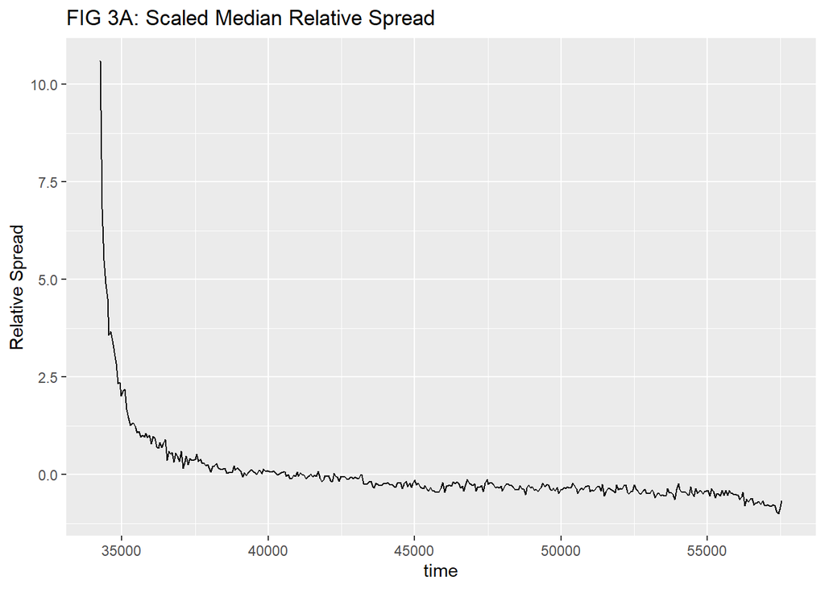

```r
rs <- LiqSample[,.(rs=median(rs)), by="time"][,.(time,rs=scale(rs))]

ggplot(rs, aes(time, rs.V1))+
  geom_line()+
  labs(x="time",y="Relative Spread", title ="FIG 3A: Scaled Median Relative Spread")
```

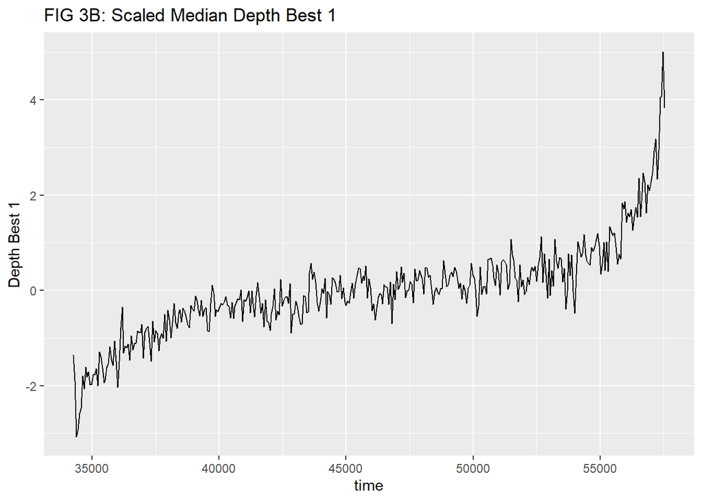

```r
dbest <- LiqSample[,.(dbest=median(dbest)), by="time"][,.(time,dbest=scale(dbest))]

ggplot(dbest, aes(time, dbest.V1))+
  geom_line()+
  labs(x="time",y="Depth Best 1", title ="FIG 3B: Scaled Median Depth Best 1")
```

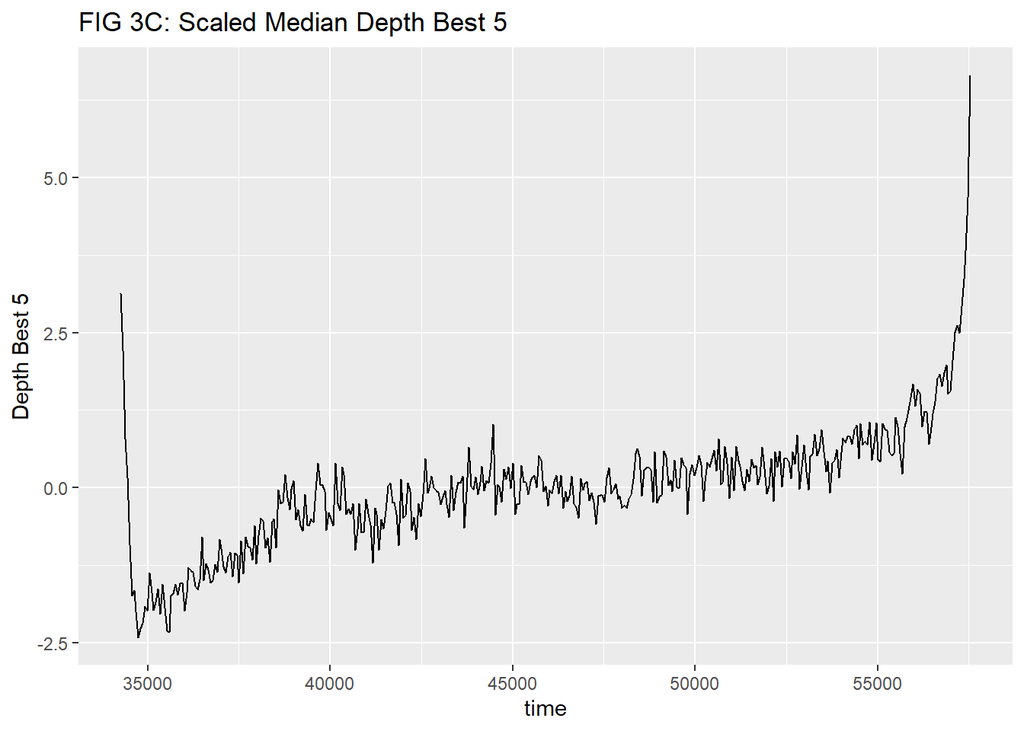

```r
dbest5 <- LiqSample[,.(dbest5=median(dbest5)), by="time"][,.(time,dbest5=scale(dbest5))]

ggplot(dbest5, aes(time, dbest5.V1))+
  geom_line()+
  labs(x="time",y="Depth Best 5", title ="FIG 3C: Scaled Median Depth Best 5")
```

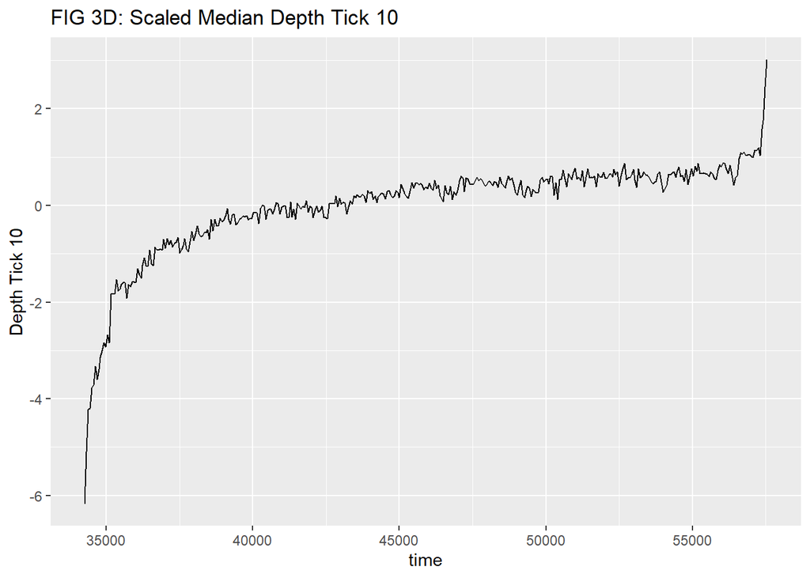

```r
dtick10 <- LiqSample[,.(dtick10=median(dtick10)), by="time"][,.(time,dtick10=scale(dtick10))]

ggplot(dtick10, aes(time, dtick10.V1))+
  geom_line()+
  labs(x="time",y="Depth Tick 10", title ="FIG 3D: Scaled Median Depth Tick 10")
```

The following step consists on studying the relationship between market capitalization (market value of equity) and liquidity. For that, you need the following file: CapGroup.txt. This file has only two columns: the first one contains the stock code (1 to 120). The second column equals “1” for large caps, “2” for medium caps, and “3” for small caps.

Take all the data in LiqSample.txt that corresponds to large caps and obtain the cross-sectional average intraday regular patterns in liquidity as before. Then, repeat the process for medium caps, and, lastly, for small caps. You must end up with three estimates of intraday regular patterns for each metric, one for each market capitalization subsample.

Plot the estimated regular patterns of the three market capitalization subsamples per metric (Figures 4a to 4d). What do you conclude about the relationship between market capitalization and liquidity?

```r
rm(list = ls())
LiqSample <- fread("C:/Users/Jt_an/Google Drive/GSE - Finance/2 trim_/HFT/Assignments/FIRST/LiqSample.txt")
CapGroup <- fread ("C:/Users/Jt_an/Google Drive/GSE - Finance/2 trim_/HFT/Assignments/FIRST/CapGroup.txt")
LiqSample <- LiqSample[CapGroup, on=c(stock="Stock")]
```

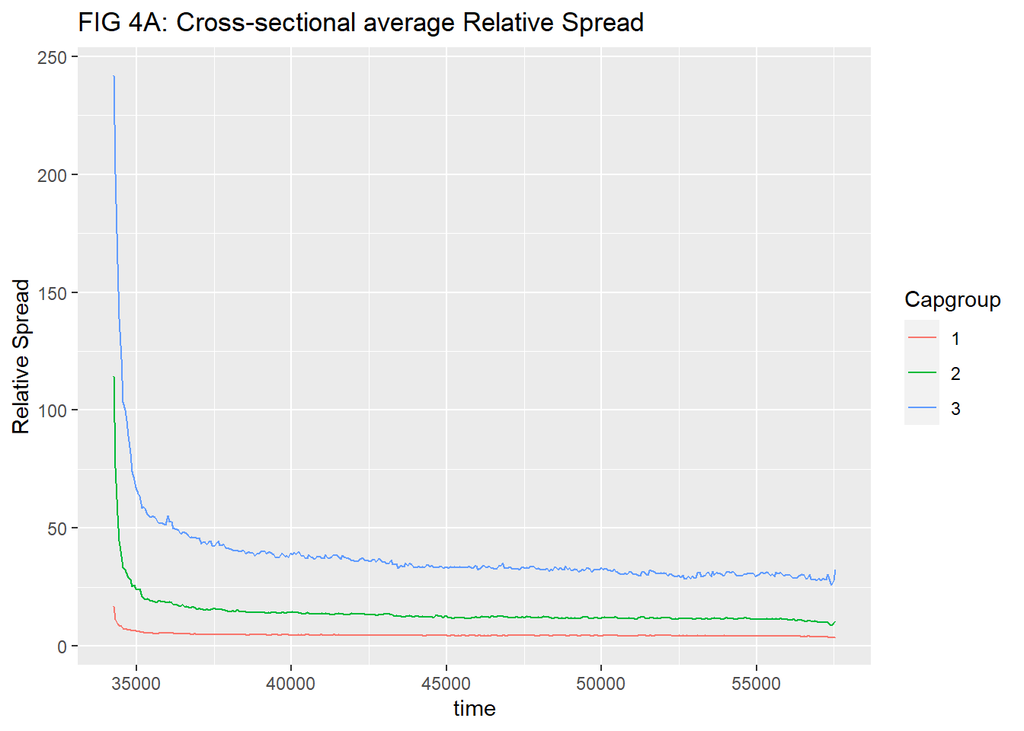

```r
rs_1 <- LiqSample[Capgroup==1,.(Capgroup,rs=mean(rs)), by="time"]
rs_2 <- LiqSample[Capgroup==2,.(Capgroup,rs=mean(rs)), by="time"]
rs_3 <- LiqSample[Capgroup==3,.(Capgroup,rs=mean(rs)), by="time"]
rs<-rbind(rs_1,rs_2,rs_3)
rs$Capgroup <- factor(rs$Capgroup)

ggplot(rs, aes(time, rs,colour=Capgroup))+
  geom_line()+
  labs(x="time",y="Relative Spread",title="FIG 4A: Cross-sectional average Relative Spread")
```

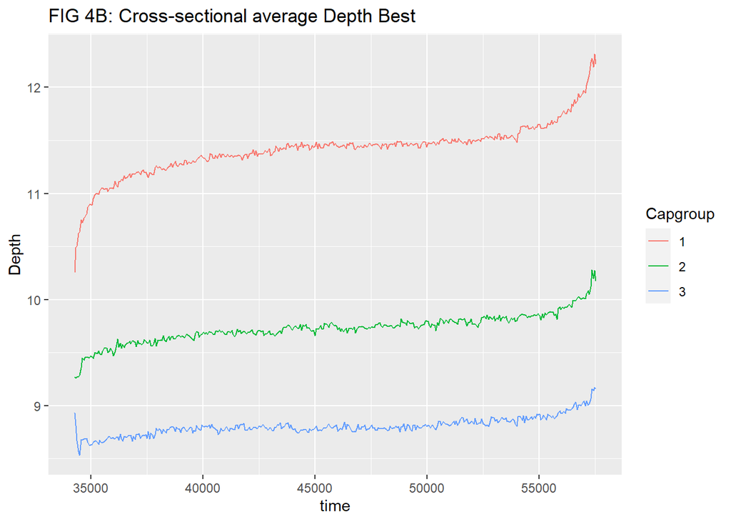

```r
dbest_1 <- LiqSample[Capgroup==1,.(Capgroup,dbest=mean(dbest)), by="time"]
dbest_2 <- LiqSample[Capgroup==2,.(Capgroup,dbest=mean(dbest)), by="time"]
dbest_3 <- LiqSample[Capgroup==3,.(Capgroup,dbest=mean(dbest)), by="time"]
dbest<-rbind(dbest_1,dbest_2,dbest_3)
dbest$Capgroup <- factor(dbest$Capgroup)

ggplot(dbest, aes(time, dbest,colour=Capgroup))+
  geom_line()+
  labs(x="time",y="Depth",title="FIG 4B: Cross-sectional average Depth Best")
```

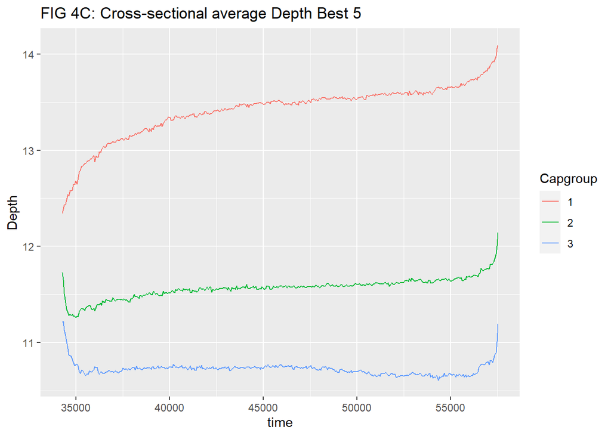

```r
dbest5_1 <- LiqSample[Capgroup==1,.(Capgroup,dbest5=mean(dbest5)), by="time"]
dbest5_2 <- LiqSample[Capgroup==2,.(Capgroup,dbest5=mean(dbest5)), by="time"]
dbest5_3 <- LiqSample[Capgroup==3,.(Capgroup,dbest5=mean(dbest5)), by="time"]
dbest5<-rbind(dbest5_1,dbest5_2,dbest5_3)
dbest5$Capgroup <- factor(dbest5$Capgroup)

ggplot(dbest5, aes(time, dbest5,colour=Capgroup))+
  geom_line()+
  labs(x="time",y="Depth",title="FIG 4C: Cross-sectional average Depth Best 5")
```

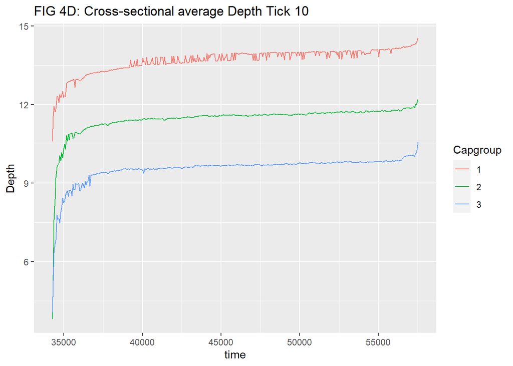

```r
dtick10_1 <- LiqSample[Capgroup==1,.(Capgroup,dtick10=mean(dtick10)), by="time"]
dtick10_2 <- LiqSample[Capgroup==2,.(Capgroup,dtick10=mean(dtick10)), by="time"]
dtick10_3 <- LiqSample[Capgroup==3,.(Capgroup,dtick10=mean(dtick10)), by="time"]
dtick10<-rbind(dtick10_1,dtick10_2,dtick10_3)
dtick10$Capgroup <- factor(dtick10$Capgroup)

ggplot(dtick10, aes(time, dtick10,colour=Capgroup))+
  geom_line()+
  labs(x="time",y="Depth",title="FIG 4D: Cross-sectional average Depth Tick 10")
```

## EXERCISE 3

```r
rm(list = ls())
NasdaqVolat <- fread("C:/Users/Jt_an/Google Drive/GSE - Finance/2 trim_/HFT/Assignments/FIRST/NasdaqVolat.txt")
LiqLOB <- fread ("C:/Users/Jt_an/Google Drive/GSE - Finance/2 trim_/HFT/Assignments/FIRST/LiqLOB.txt")
CapGroup <- fread ("C:/Users/Jt_an/Google Drive/GSE - Finance/2 trim_/HFT/Assignments/FIRST/CapGroup.txt")
```

Select the 10 days with highest volatility and the 10 days with lowest volatility for each stock. Then, extract the data corresponding to the selected days from LiqLOB.txt. This file contains the liquidity statistics per stock, day, and 1-minute snapshot of the LOB. Make sure you add a column identifying whether a given stock-day is a high or a low volatility day. Alternatively, you can create two files, one for high volatility days and another with low volatility days.

```r
vol_order <- NasdaqVolat[order(stock,-volat)]

vol_high<-vol_order[,lapply(.SD,  function(i) head(i, 10)), by="stock"]
vol_low<-vol_order[,lapply(.SD,  function(i) tail(i, 10)), by="stock"]

vol_high <- LiqLOB[vol_high, on=c(stock="stock",date="date")]
vol_low <- LiqLOB[vol_low, on=c(stock="stock",date="date")]
```

For each stock, compute the daily median liquidity for both high volatility and low volatility days. You should end up with 240 median liquidity estimates per metric (120 stocks x 2 medians for low and high volatility days).

```r
liq_high_rs <- vol_high[,.(median=median(rs)) ,by="stock"]
liq_high_rs <- cbind(liq_high_rs, "Type of day"=rep("1",120))


liq_low_rs <- vol_low[,.(median=median(rs)) ,by="stock"]
liq_low_rs<- cbind(liq_low_rs, "Type of day"=rep("0",120))

liq_rs<- rbind(liq_high_rs,liq_low_rs)

liq_rs <- liq_rs[CapGroup, on=c(stock="Stock")]
```

```r
liq_high_dbest <- vol_high[,.(median=median(dbest)) ,by="stock"]
liq_high_dbest <- cbind(liq_high_dbest, "Type of day"=rep("1",120))


liq_low_dbest <- vol_low[,.(median=median(dbest)) ,by="stock"]
liq_low_dbest<- cbind(liq_low_dbest, "Type of day"=rep("0",120))

liq_dbest<- rbind(liq_high_dbest,liq_low_dbest)

liq_dbest <- liq_dbest[CapGroup, on=c(stock="Stock")]
```

```r
liq_high_dbest5 <- vol_high[,.(median=median(dbest5)) ,by="stock"]
liq_high_dbest5 <- cbind(liq_high_dbest5, "Type of day"=rep("1",120))


liq_low_dbest5 <- vol_low[,.(median=median(dbest5)) ,by="stock"]
liq_low_dbest5<- cbind(liq_low_dbest5, "Type of day"=rep("0",120))

liq_dbest5<- rbind(liq_high_dbest5,liq_low_dbest5)

liq_dbest5 <- liq_dbest5[CapGroup, on=c(stock="Stock")]
```

```r
liq_high_dtick10 <- vol_high[,.(median=median(dtick10)) ,by="stock"]
liq_high_dtick10 <- cbind(liq_high_dtick10, "Type of day"=rep("1",120))


liq_low_dtick10 <- vol_low[,.(median=median(dtick10)) ,by="stock"]
liq_low_dtick10<- cbind(liq_low_dtick10, "Type of day"=rep("0",120))

liq_dtick10<- rbind(liq_high_dtick10,liq_low_dtick10)

liq_dtick10 <- liq_dtick10[CapGroup, on=c(stock="Stock")]
```

Using the Wilcoxon ranksum test for equality of medians (https://data.library.virginia.edu/the-wilcoxon-rank-sum-test/), determine if there are significant differences in liquidity between high volatility and low volatility days. Then, repeat the exercise but controlling for market capitalization, that is, performing separated tests for large, medium, and small caps. Summarize your findings in Table 1.

```r
wt_dbest_1 <- wilcox.test(median~`Type of day`, data= liq_dbest[liq_dbest$Capgroup==1])
wt_dbest_2 <- wilcox.test(median~`Type of day`, data= liq_dbest[liq_dbest$Capgroup==2])
wt_dbest_3 <-wilcox.test(median~`Type of day`, data= liq_dbest[liq_dbest$Capgroup==3])
wt_dbest_all <-wilcox.test(median~`Type of day`, data= liq_dbest)
```

```r
wt_dbest5_1 <- wilcox.test(median~`Type of day`, data= liq_dbest5[liq_dbest5$Capgroup==1])
wt_dbest5_2 <- wilcox.test(median~`Type of day`, data= liq_dbest5[liq_dbest5$Capgroup==2])
wt_dbest5_3 <- wilcox.test(median~`Type of day`, data= liq_dbest5[liq_dbest5$Capgroup==3])
wt_dbest5_all <- wilcox.test(median~`Type of day`, data= liq_dbest5)
```

```r
wt_dtick10_1 <- wilcox.test(median~`Type of day`, data= liq_dtick10[liq_dtick10$Capgroup==1])
wt_dtick10_2 <- wilcox.test(median~`Type of day`, data= liq_dtick10[liq_dtick10$Capgroup==2])
wt_dtick10_3 <- wilcox.test(median~`Type of day`, data= liq_dtick10[liq_dtick10$Capgroup==3])
wt_dtick_all <-wilcox.test(median~`Type of day`, data= liq_dtick10)
```

```r
wt_rs_1 <- wilcox.test(median~`Type of day`, data= liq_rs[liq_rs$Capgroup==1])
wt_rs_2 <- wilcox.test(median~`Type of day`, data= liq_rs[liq_rs$Capgroup==2])
wt_rs_3 <- wilcox.test(median~`Type of day`, data= liq_rs[liq_rs$Capgroup==3])
wt_rs_all <- wilcox.test(median~`Type of day`, data= liq_rs)
```

```r
wt_data <- data.frame("RS"=c(wt_rs_1$p.value,wt_rs_2$p.value,wt_rs_3$p.value,wt_rs_all$p.value),
                      "DBest"=c(wt_dbest_1$p.value,wt_dbest_2$p.value,wt_dbest_3$p.value,wt_dbest_all$p.value),
                      "DBest5"=c(wt_dbest5_1$p.value,wt_dbest5_2$p.value,wt_dbest5_3$p.value,wt_dbest5_all$p.value),
                      "Dtick10"=c(wt_dtick10_1$p.value,wt_dtick10_2$p.value,wt_dtick10_3$p.value,wt_dtick_all$p.value))
rownames(wt_data)<-c("big","medium","small","all")
```

```r
kable(wt_data)
```

[output not shown]

To provide robustness to your conclusion, run the following regression for each daily liquidity metric:

$$Liq_{i,d}=\beta_0+\beta_1HVol_{i,d}+\epsilon_{i,d}$$

where $Liq_{i,d}$ is the liquidity metric for stock i and day d, $HVol_{i,d}$ is a dummy variable that equals 1 for high volatility days and 0 otherwise, and $\epsilon_{i,d}$ is the residual of the regression. Report the estimated beta coefficients in Table 2. Notice that you have data on 120 stocks, 20 days per stock, but the days are not the same for all stocks. So, this is not a proper panel. Therefore, just estimate the model by OLS

```r
lm_rs<-lm(liq_rs$median~liq_rs$`Type of day`)

lm_dbest<-lm(liq_dbest$median~liq_dbest$`Type of day`)

lm_dbest5<-lm(liq_dbest5$median~liq_dbest5$`Type of day`)

lm_dtick10<-lm(liq_dtick10$median~liq_dtick10$`Type of day`)

lm_data <- data.frame("RS"=c(lm_rs$coefficients),"DBest"=lm_dbest$coefficients,"DBest5"=lm_dbest5$coefficients,"Dtick10"=lm_dtick10$coefficients)
rownames(lm_data)=c("intercept","beta")

kable(lm_data)
```

[output not shown]

# Problem set 2

```r
library(data.table)
library(reshape2)
library(ggplot2)
#Parameters
p<-.65 #probability of buyer-initiated trade
theta_0<-0.5 #initial dealer's belief
pi<-0.3 #probability of informed trader
v_H<-102
v_L<-98
```

Functions

```r
#Binomial sample generator
generate_sample_fun<-function(size,p){#1 is buyer initiated, -1 seller
sample(c(1,-1),size,TRUE,prob=c(p,1-p))
}

#trade paths

trade_paths_dt<-function(q,size,p){
  m<-c()
  for (i in 1:q){
    set.seed(4*i*q)
    m<-cbind(m,generate_sample_fun(size,p))
    dat<-cbind(as.data.frame(m))
  }
return(as.data.frame(dat))
}

#A generic data.frame plotting function

plotter<-function(data){data<-as.data.table(data)
  dat<-as.data.table(cbind(id=1:length(data[[1]]),data))
  datmelt<-melt(id.vars="id",dat)
 ggplot(datmelt,
         aes(x = id, y = value, color=variable))+theme_bw()+
    xlab("X LABEL")+ylab("Y LABEL")+geom_line()+
    ggtitle("TITLE")
}

#Order imbalance function
OI_fun<-function(trades_){OI_<-c()
for (i in 1:length(trades_)){OI_[i]<-(length(trades_[trades_[1:i]==1])-length(trades_[trades_[1:i]==-1]))/(length(trades_[trades_[1:i]==1])+length(trades_[trades_[1:i]==-1]))}
return(OI_)
}
#Theta function

theta_fun<-function(trade_sequence,pi,theta_0){theta_seq<-c(theta_0)
  for(i in 2:length(trade_sequence)){
    if(trade_sequence[i-1]==1){
      theta_seq[i]<-theta_seq[i-1]*((.5*(1+pi))/((pi*theta_seq[i-1])+.5*(1-pi)))
    }
    else(theta_seq[i]<-theta_seq[i-1]*((.5*(1-pi))/((pi*(1-theta_seq[i-1]))+.5*(1-pi))))
  }
return(theta_seq)
}
#Price function
price_fun<-function(beliefs,high,low){
  beliefs*high+(1-beliefs)*low
}#recall vectorized function nature: applies over all vector, regardless of recursion or not

#Pricing error function
pricing_error_fun<-function(price_series){
  (price_series-v_H)^2
}
```

1a-1c

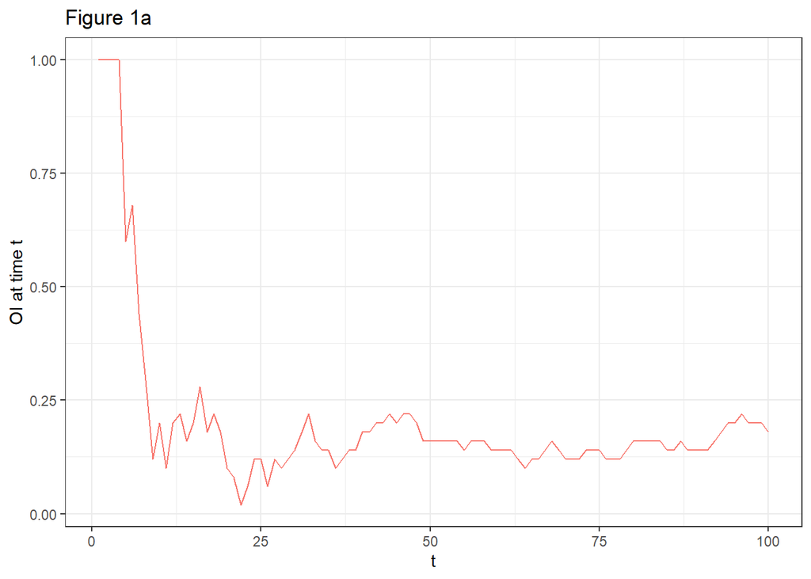

```r
#Generating a random trading session
one_session<-as.data.table((trade_paths_dt(1,100,p)))#sequence of trades, one per t
#names(one_session)<-c("type_of_trade")
#time series of theta
one_theta_series<-theta_fun(one_session[[1]],pi,theta_0)
#accumulated OI
one_OI_series<-OI_fun(one_session[[1]])
#now we build the time series of prices, which under perfect competition are equal to the efficient price
one_price_series<-price_fun(one_theta_series,v_H,v_L)
one_pricing_error_series<-pricing_error_fun(one_price_series)
#apply plotter to each of these functions
plotter(one_OI_series)+ggtitle("Figure 1a")+ theme(legend.position="none")+ylab("OI at time t")+xlab("t")
```

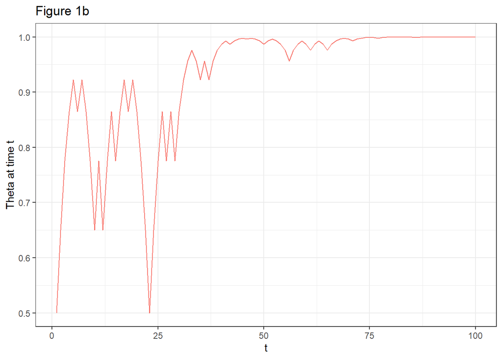

```r
plotter(one_theta_series)+ggtitle("Figure 1b")+ theme(legend.position="none")+ylab("Theta at time t")+xlab("t")
```

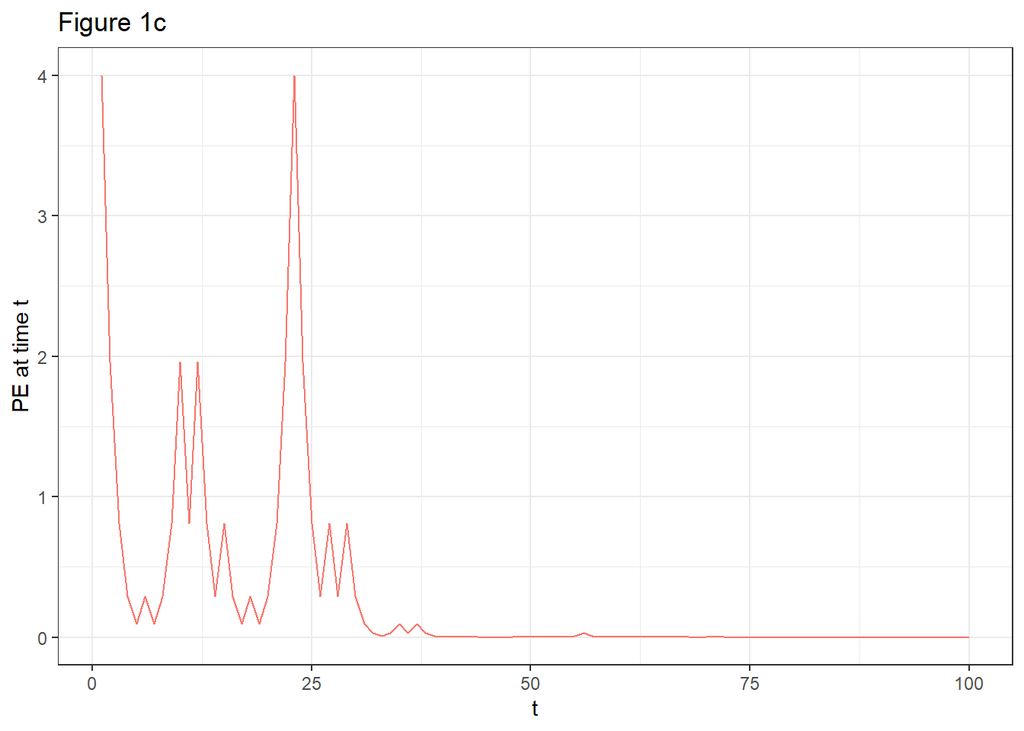

```r
plotter(one_pricing_error_series)+ggtitle("Figure 1c")+ theme(legend.position="none")+ylab("PE at time t")+xlab("t")
```

Figure 2

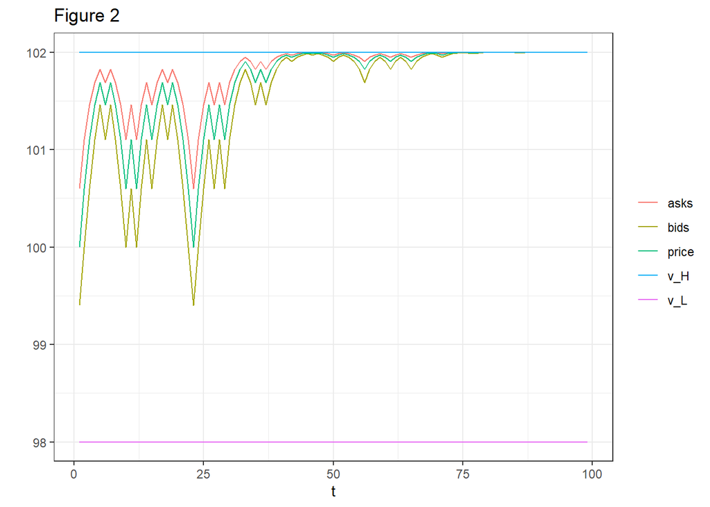

```r
#ask quotes
asks_<-c()

for (i in 2:length(one_price_series)){
  asks_[i]<-one_price_series[i-1]+(((pi*one_theta_series[i-1])*(1-one_theta_series[i-1])))/((pi*(one_theta_series[i-1]))+.5*(1-pi))*(v_H-v_L)

}
#bid quotes
bids_<-c()
#NOTE: asks and bids have one initial NA due to  formula using t-1
for (i in 2:length(one_price_series)){
  bids_[i]<-one_price_series[i-1]-(((pi*one_theta_series[i-1])*(1-one_theta_series[i-1])))/((pi*(1-one_theta_series[i-1]))+.5*(1-pi))*(v_H-v_L)
}
#plotting everything
plotter(as.data.table(cbind(asks=asks_[2:100],bids=bids_[2:100],price=one_price_series[1:99],v_H=rep(v_H,99),v_L=rep(v_L,99))))+ggtitle("Figure 2")+ theme(legend.title = element_blank())+ylab("")+xlab("t")
```

Figures 3a-3c

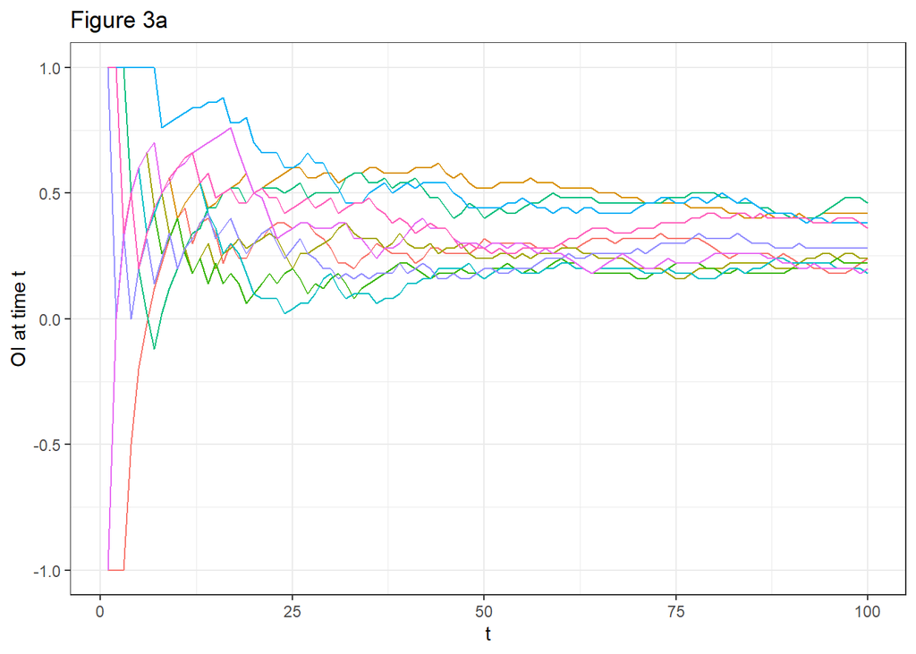

```r
#10 random trading sessions
ten_sessions<-as.data.table((trade_paths_dt(10,100,p)))
#10 order imbalance time series
ten_OI_series<-lapply(ten_sessions,OI_fun)
#10 time series of theta
ten_theta_series<-lapply(ten_sessions,theta_fun,pi,theta_0)
#10 price and pricing error time series
ten_price_series<-lapply(ten_theta_series,price_fun,v_H,v_L)
ten_pricing_error_series<-lapply(ten_price_series,pricing_error_fun)

#Plotting each case

plotter(ten_OI_series)+ggtitle("Figure 3a")+ theme(legend.title = element_blank())+ylab("OI at time t")+xlab("t")+ theme(legend.position = "none")
```

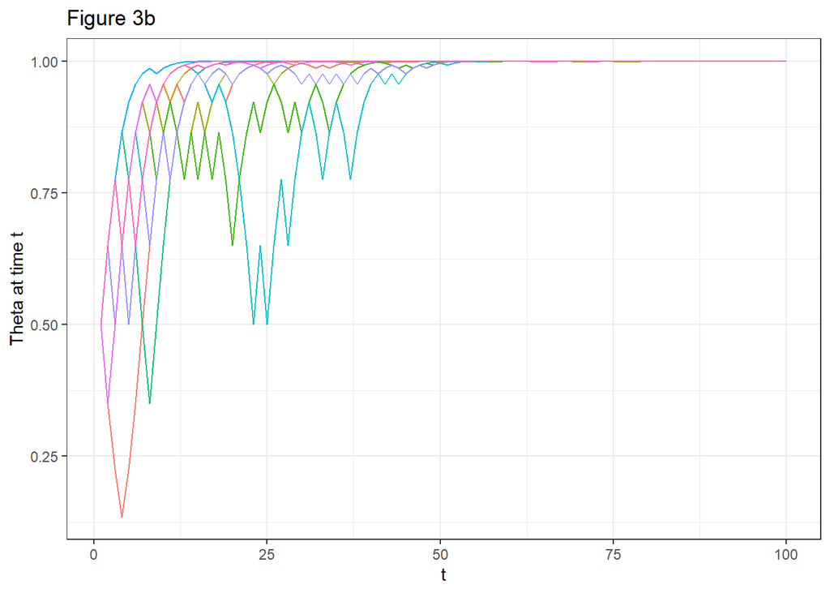

```r
plotter(ten_theta_series)+ggtitle("Figure 3b")+ theme(legend.position = "none")+ylab("Theta at time t")+xlab("t")
```

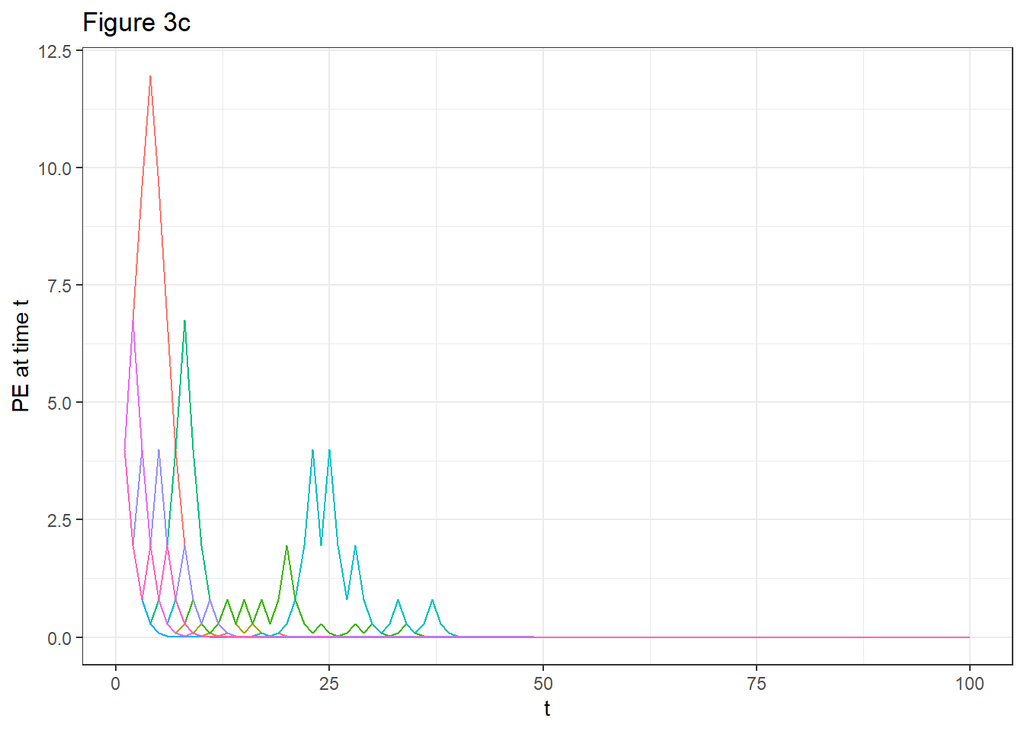

```r
plotter(ten_pricing_error_series)+ggtitle("Figure 3c")+ theme(legend.title = element_blank())+ylab("PE at time t")+xlab("t")+ theme(legend.position = "none")
```

Figures 4a-4c

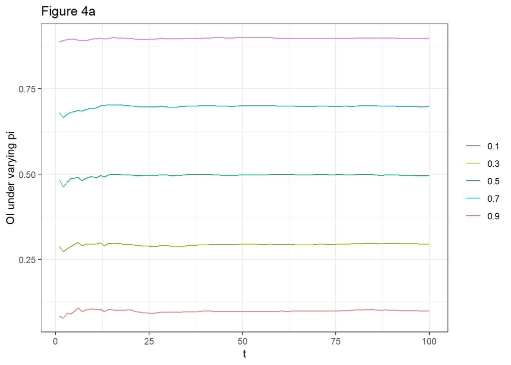

```r
#First we need to generate 500 trading sessions per value of p of a buying initiated trade (which is a functin of pi)
pi_vector_<-c(0.1,0.3,0.5,0.7,0.9)
p_vector_<-c() #a vector of ps
for (i in 1:length(pi_vector_)){
  p_vector_[i]<-(1+pi_vector_[i])*.5
}
#Now we can generate 500, 100-trade trading sessions per p
master_dt<-as.data.table(c())

for (i in 1:length(pi_vector_)){
  master_dt<-cbind(master_dt,trade_paths_dt(500,100,p_vector_[i]))}

#A quick sanity check for the trade session simulations under different ps (sum should be greater the larger the p)
#sum(master_dt[,1:500])
#sum(master_dt[,501:1000])
#sum(master_dt[,1001:1500])
#sum(master_dt[,1501:2000])
#sum(master_dt[,2001:2500])

#Simulating and averaging 500 order imbalances paths per pi
#pi 0.1
fivehundred_OI_0.1<-as.data.table(lapply(master_dt[,1:500],OI_fun))

average_OI_500_0.1<-fivehundred_OI_0.1[,rowMeans(.SD)]

#pi 0.3
fivehundred_OI_0.3<-as.data.table(lapply(master_dt[,501:1000],OI_fun))

average_OI_500_0.3<-fivehundred_OI_0.3[,rowMeans(.SD)]
#pi 0.5
fivehundred_OI_0.5<-as.data.table(lapply(master_dt[,1001:1500],OI_fun))

average_OI_500_0.5<-fivehundred_OI_0.5[,rowMeans(.SD)]
#pi 0.7
fivehundred_OI_0.7<-as.data.table(lapply(master_dt[,1501:2000],OI_fun))

average_OI_500_0.7<-fivehundred_OI_0.7[,rowMeans(.SD)]
#pi 0.9
fivehundred_OI_0.9<-as.data.table(lapply(master_dt[,2001:2500],OI_fun))

average_OI_500_0.9<-fivehundred_OI_0.9[,rowMeans(.SD)]

#into a single dt
avg_OI_500<-as.data.table(cbind(average_OI_500_0.1=average_OI_500_0.1,average_OI_500_0.3=average_OI_500_0.3,average_OI_500_0.5=average_OI_500_0.5,average_OI_500_0.7=average_OI_500_0.7,average_OI_500_0.9=average_OI_500_0.9))

#Simulating and averaging 500 theta paths per pi
#pi 0.1
fivehundred_theta_0.1<-as.data.table(lapply(master_dt[,1:500],theta_fun,pi_vector_[1],theta_0))

average_theta_500_0.1<-fivehundred_theta_0.1[,rowMeans(.SD)]
#pi 0.3
fivehundred_theta_0.3<-as.data.table(lapply(master_dt[,501:1000],theta_fun,pi_vector_[2],theta_0))

average_theta_500_0.3<-fivehundred_theta_0.3[,rowMeans(.SD)]
#pi 0.5
fivehundred_theta_0.5<-as.data.table(lapply(master_dt[,1001:1500],theta_fun,pi_vector_[3],theta_0))

average_theta_500_0.5<-fivehundred_theta_0.5[,rowMeans(.SD)]
#pi 0.7
fivehundred_theta_0.7<-as.data.table(lapply(master_dt[,1501:2000],theta_fun,pi_vector_[4],theta_0))

average_theta_500_0.7<-fivehundred_theta_0.7[,rowMeans(.SD)]
#pi 0.9
fivehundred_theta_0.9<-as.data.table(lapply(master_dt[,2001:2500],theta_fun,pi_vector_[5],theta_0))

average_theta_500_0.9<-fivehundred_theta_0.9[,rowMeans(.SD)]

#into a single dt
avg_theta_500<-as.data.table(cbind(average_theta_500_0.1=average_theta_500_0.1,average_theta_500_0.3=average_theta_500_0.3,average_theta_500_0.5=average_theta_500_0.5,average_theta_500_0.7=average_theta_500_0.7,average_theta_500_0.9=average_theta_500_0.9))

#Simulating and averaging 500 Pricing Error paths per pi
#pi 0.1
fivehundred_pricingerrors_0.1<-as.data.table(pricing_error_fun(price_fun(fivehundred_theta_0.1,v_H,v_L)))
average_pricing_errors_500_0.1<-fivehundred_pricingerrors_0.1[,rowMeans(.SD)]

#pi 0.3
fivehundred_pricingerrors_0.3<-as.data.table(pricing_error_fun(price_fun(fivehundred_theta_0.3,v_H,v_L)))
average_pricing_errors_500_0.3<-fivehundred_pricingerrors_0.3[,rowMeans(.SD)]

#pi 0.5
fivehundred_pricingerrors_0.5<-as.data.table(pricing_error_fun(price_fun(fivehundred_theta_0.5,v_H,v_L)))
average_pricing_errors_500_0.5<-fivehundred_pricingerrors_0.5[,rowMeans(.SD)]

#pi 0.7
fivehundred_pricingerrors_0.7<-as.data.table(pricing_error_fun(price_fun(fivehundred_theta_0.7,v_H,v_L)))
average_pricing_errors_500_0.7<-fivehundred_pricingerrors_0.7[,rowMeans(.SD)]

#pi 0.9
fivehundred_pricingerrors_0.9<-as.data.table(pricing_error_fun(price_fun(fivehundred_theta_0.9,v_H,v_L)))
average_pricing_errors_500_0.9<-fivehundred_pricingerrors_0.9[,rowMeans(.SD)]

#into a single dt
avg_pricing_errors_500<-as.data.table(cbind(average_pricing_errors_500_0.1=average_pricing_errors_500_0.1,average_pricing_errors_500_0.3=average_pricing_errors_500_0.3,average_pricing_errors_500_0.5=average_pricing_errors_500_0.5,average_pricing_errors_500_0.7=average_pricing_errors_500_0.7,average_pricing_errors_500_0.9=average_pricing_errors_500_0.9))

#names(avg_pricing_errors_500)<-c("average_pricing_errors_500_0.1","average_pricing_errors_500_0.2","","","")

#plotting

setnames(avg_OI_500,names(avg_OI_500),c("0.1","0.3","0.5","0.7","0.9"))
setnames(avg_theta_500,names(avg_theta_500),c("0.1","0.3","0.5","0.7","0.9"))
setnames(avg_pricing_errors_500,names(avg_pricing_errors_500),c("0.1","0.3","0.5","0.7","0.9"))

plotter(avg_OI_500)+ggtitle("Figure 4a")+theme(legend.title = element_blank())+ylab("OI under varying pi")+xlab("t")
```

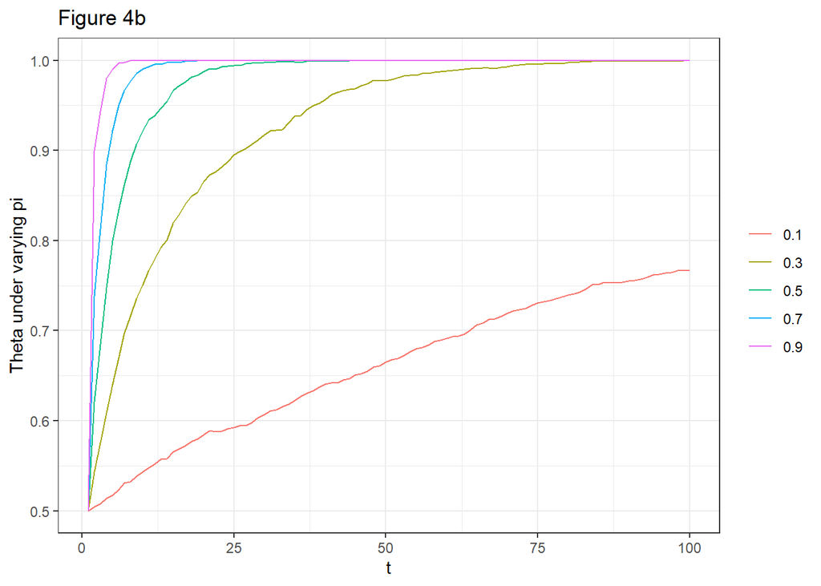

```r
plotter(avg_theta_500)+ggtitle("Figure 4b")+theme(legend.title = element_blank())+ylab("Theta under varying pi")+xlab("t")
```

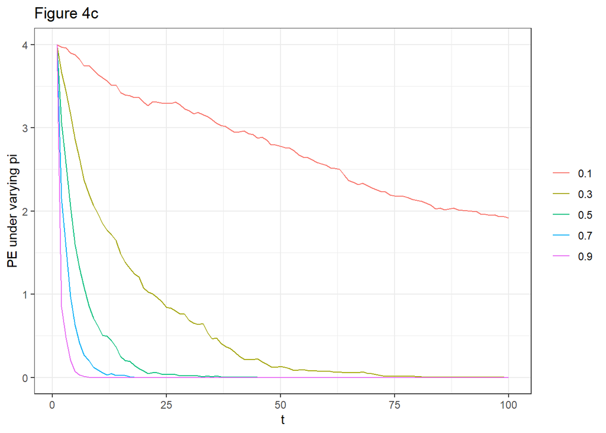

```r
plotter(avg_pricing_errors_500)+ggtitle("Figure 4c")+theme(legend.title = element_blank())+ylab("PE under varying pi")+xlab("t")
```

Figures 5a-5c

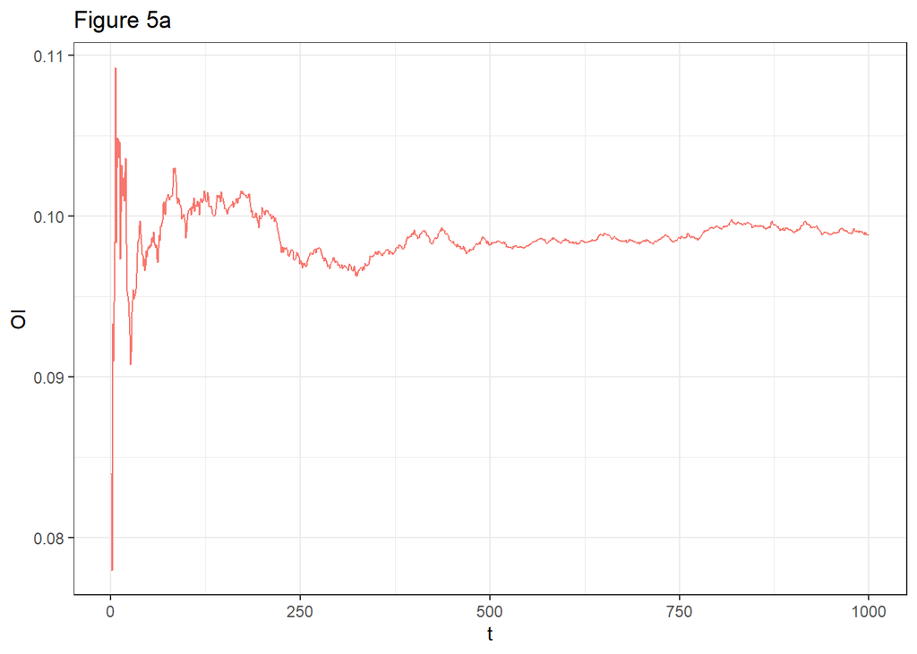

```r
#now we want to investigate if convergence happens for pi=0.1 if the number of trades goes to 1000 instead of 100
thousand_trade_fivehundred_sessions<-as.data.table(trade_paths_dt(500,1000,p_vector_[1]))#p of .55 corresponds to pi of 0.1
#on to computing the average order imbalance across the 500 1000-trade sessions
thousand_OI_0.1<-as.data.table(lapply(thousand_trade_fivehundred_sessions,OI_fun))

average_OI_1000_0.1<-thousand_OI_0.1[,rowMeans(.SD)]
#now the thetas
thousand_theta_0.1<-as.data.table(lapply(thousand_trade_fivehundred_sessions,theta_fun,pi_vector_[1],theta_0))

average_theta_1000_0.1<-thousand_theta_0.1[,rowMeans(.SD)]

#and lastly, the Pricing Errors
thousand_pricingerrors_0.1<-as.data.table(pricing_error_fun(price_fun(thousand_theta_0.1,v_H,v_L)))

average_pricing_errors_1000_0.1<-thousand_pricingerrors_0.1[,rowMeans(.SD)]


#plotting
plotter(average_OI_1000_0.1)+ggtitle("Figure 5a")+theme(legend.position="none")+ylab("OI")+xlab("t")
```

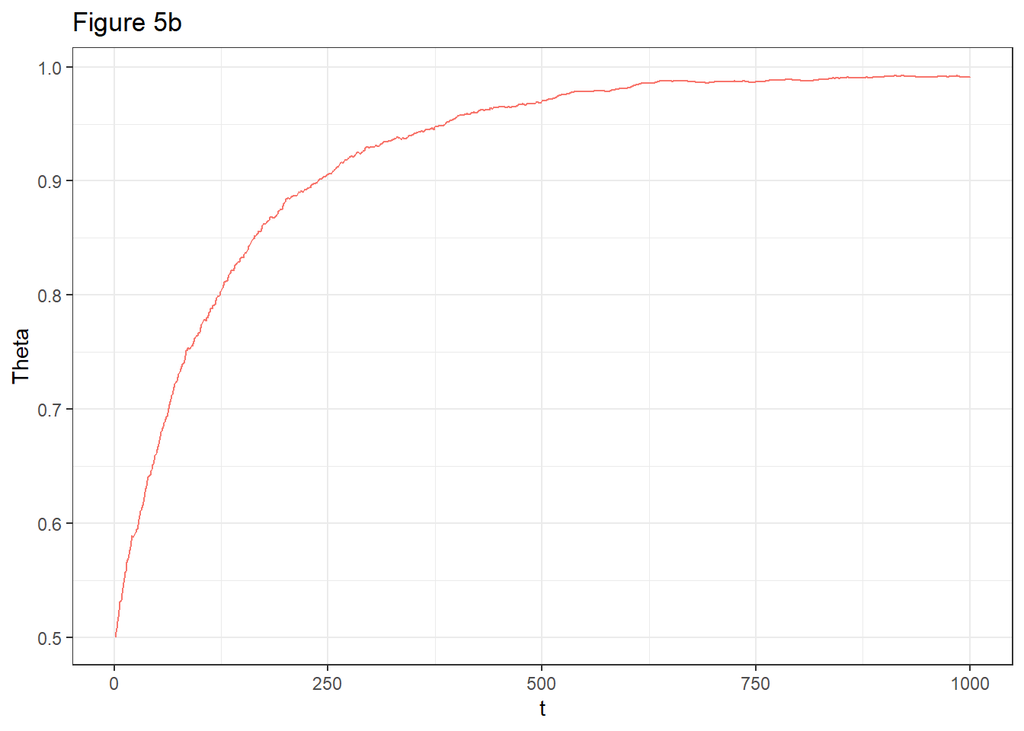

```r
plotter(average_theta_1000_0.1)+ggtitle("Figure 5b")+ theme(legend.position="none")+ylab("Theta")+xlab("t")
```

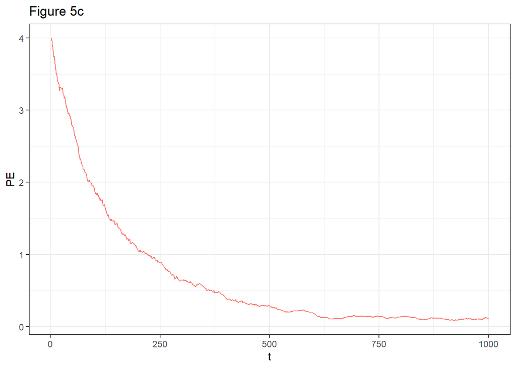

```r
plotter(average_pricing_errors_1000_0.1)+ggtitle("Figure 5c")+ theme(legend.position="none")+ylab("PE")+xlab("t")
```

Figure 6

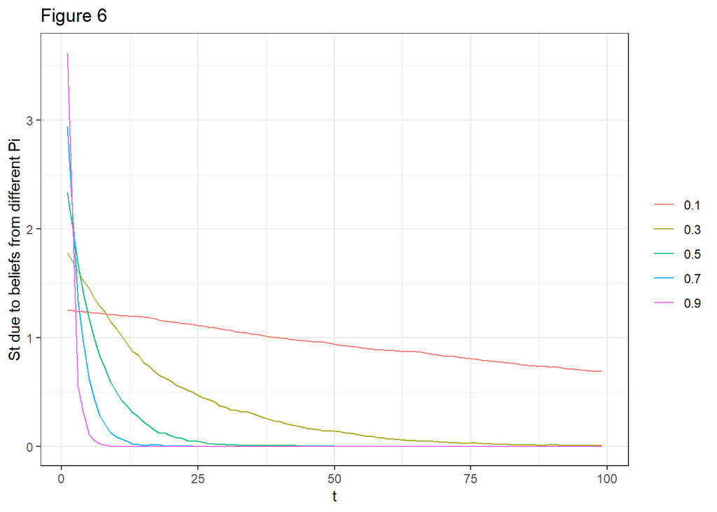

```r
#A function for computing the time series of the spread over the trading session
spread_fun<-function(theta,pi,v_H,v_L){
  spread<-c()
  for (i in 2:length(theta)){
    spread[i]<-(((pi*theta[i-1]*(1-theta[i-1]))/(pi*theta[i-1]+0.5*(1-pi)))+((pi*theta[i-1]*(1-theta[i-1]))/(pi*(1-theta[i-1]+0.5*(1-pi)))))*(v_H-v_L)
  }
  return(spread)
}
#Applying the function to 500 simulations for each pi and averaging them
#pi 0.1
fivehundred_st_0.1<-as.data.table(lapply(fivehundred_theta_0.1,spread_fun,pi_vector_[1],v_H,v_L))
average_st_500_0.1<-fivehundred_st_0.1[,rowMeans(.SD)]
#pi 0.3
fivehundred_st_0.3<-as.data.table(lapply(fivehundred_theta_0.3,spread_fun,pi_vector_[2],v_H,v_L))
average_st_500_0.3<-fivehundred_st_0.3[,rowMeans(.SD)]
#pi 0.5
fivehundred_st_0.5<-as.data.table(lapply(fivehundred_theta_0.5,spread_fun,pi_vector_[3],v_H,v_L))
average_st_500_0.5<-fivehundred_st_0.5[,rowMeans(.SD)]
#pi 0.7
fivehundred_st_0.7<-as.data.table(lapply(fivehundred_theta_0.7,spread_fun,pi_vector_[4],v_H,v_L))
average_st_500_0.7<-fivehundred_st_0.7[,rowMeans(.SD)]
#pi 0.9
fivehundred_st_0.9<-as.data.table(lapply(fivehundred_theta_0.9,spread_fun,pi_vector_[5],v_H,v_L))
average_st_500_0.9<-fivehundred_st_0.9[,rowMeans(.SD)]

#NOTE: Missing (at t=1) values due to spread formula (eq 11) are removed from plot



plotter(cbind("0.1"=average_st_500_0.1[2:length(average_st_500_0.1)],"0.3"=average_st_500_0.3[2:length(average_st_500_0.3)],"0.5"=average_st_500_0.5[2:length(average_st_500_0.5)],"0.7"=average_st_500_0.7[2:length(average_st_500_0.7)],"0.9"=average_st_500_0.9[2:length(average_st_500_0.9)]))+ggtitle("Figure 6")+theme(legend.title = element_blank())+ylab("St due to beliefs from different Pi")+xlab("t")
```

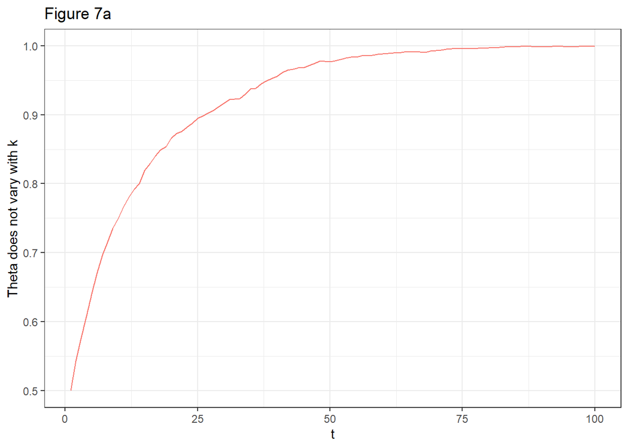

```r
#We now want to vary fundamental volatility
mu_0<-100
k<-c(2,5,10,20,50)
vec_v_H<-c()
for (i in 1:length(k)){
  vec_v_H[i]<-mu_0*(1+k[i]/100)
}
vec_v_L<-c()
for (i in 1:length(k)){
  vec_v_L[i]<-mu_0*(1-k[i]/100)
}

vec_High_Low<-vec_v_H-vec_v_L

#Now we run the simulations keeping pi at 0.3 and varying through fundamental volatilities
#master_dt[,501:1000] holds the 500 trading sessions when pi=0.3
#average_theta_500_0.3 can be called, theta function unaffected by vH or vL
#What changes is the function for price, which needs to be run several times with varying volatilities:
#for first fundamental vol, already done so we set
#4 vol
average_pricing_error_fundvol_4<-average_pricing_errors_500_0.3
#now on to the rest
#10 vol
fivehundred_pricingerrors_fundvol_10<-as.data.table(pricing_error_fun(price_fun(fivehundred_theta_0.3,vec_v_H[2],vec_v_L[2])))
average_pricing_error_fundvol_10<-fivehundred_pricingerrors_fundvol_10[,rowMeans(.SD)]
#20 vol
fivehundred_pricingerrors_fundvol_20<-as.data.table(pricing_error_fun(price_fun(fivehundred_theta_0.3,vec_v_H[3],vec_v_L[3])))
average_pricing_error_fundvol_20<-fivehundred_pricingerrors_fundvol_20[,rowMeans(.SD)]
#40 vol
fivehundred_pricingerrors_fundvol_40<-as.data.table(pricing_error_fun(price_fun(fivehundred_theta_0.3,vec_v_H[4],vec_v_L[4])))
average_pricing_error_fundvol_40<-fivehundred_pricingerrors_fundvol_40[,rowMeans(.SD)]
#100 vol
fivehundred_pricingerrors_fundvol_100<-as.data.table(pricing_error_fun(price_fun(fivehundred_theta_0.3,vec_v_H[5],vec_v_L[5])))
average_pricing_error_fundvol_100<-fivehundred_pricingerrors_fundvol_100[,rowMeans(.SD)]

#fivehundred_pricingerrors_0.3<-as.data.table(pricing_error_fun(price_fun(fivehundred_theta_0.3,v_H,v_L)))
#average_pricing_errors_500_0.3<-fivehundred_pricingerrors_0.3[,rowMeans(.SD)]


plotter(average_theta_500_0.3)+ggtitle("Figure 7a")+theme(legend.position ="none")+ylab("Theta does not vary with k")+xlab("t")#only one theta, does not depend on vH vL
```

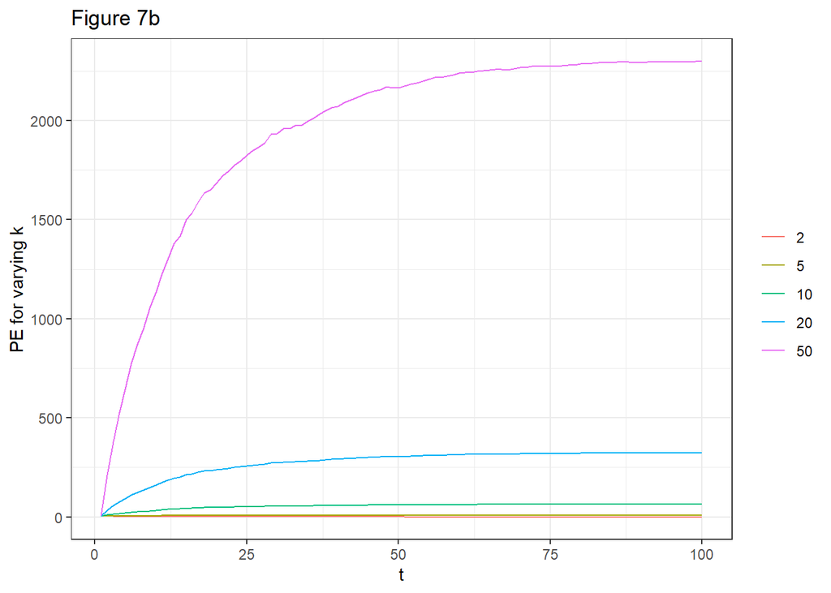

```r
plotter(cbind("2"=average_pricing_error_fundvol_4,"5"=average_pricing_error_fundvol_10,"10"=average_pricing_error_fundvol_20,"20"=average_pricing_error_fundvol_40,"50"=average_pricing_error_fundvol_100))+ggtitle("Figure 7b")+theme(legend.title = element_blank())+ylab("PE for varying k")+xlab("t")
```

Beyond Figure 7

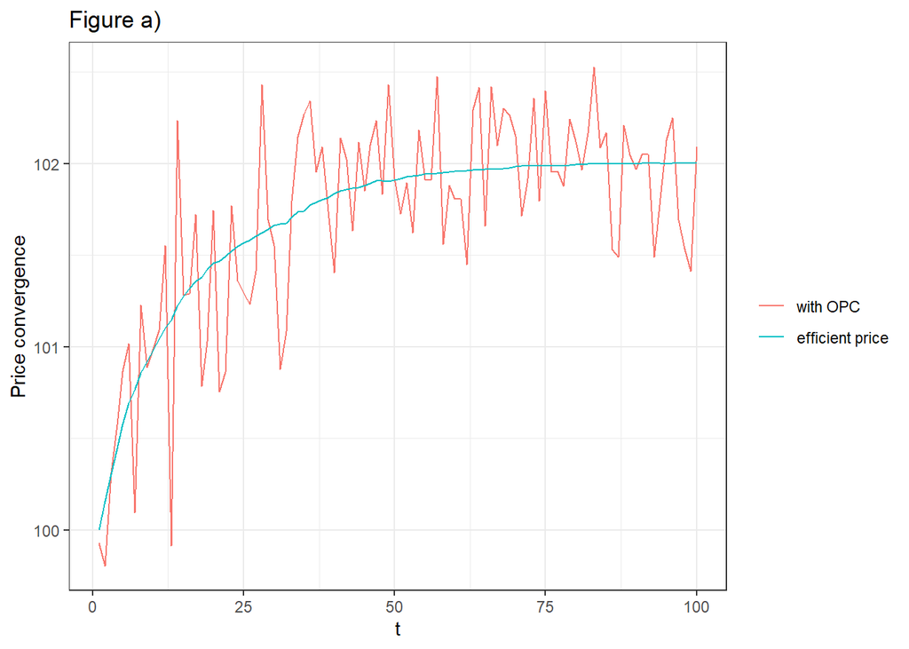

```r
#a) Now we examine price discovery instead of mu, not price
#baseline is still pi @ 0.3
#Let's arbitrarilty fix gamma at $10 per share
fixed_gamma<-10
#binding the thetas and trading sessions
feeder_fivehundred_trades_thetas_0.3<-cbind(master_dt[,501:1000],fivehundred_theta_0.3)
#Let's now build the "s(dt)" function
s_dt_500_fun<-function(trade_session,thetas,pi,high,low){# a function for computing small 's' for 500 sims from 500 thetas and 500 sessions (all of length 100, one obs lost)
  mat_500_sessions_0.3<-as.matrix(trade_session)
  mat_500_thetas_0.3<-as.matrix(thetas)
  mat_out_sdt<-matrix(nrow=nrow(mat_500_sessions_0.3),ncol=ncol(mat_500_sessions_0.3))#storing matrix
  for (j in 1:length(trade_session)){
  for (i in 2:length(trade_session[[1]])){
    if(mat_500_sessions_0.3[i,j]==-1){
      mat_out_sdt[i,j]<-((pi*mat_500_thetas_0.3[i-1,j]*(1-mat_500_thetas_0.3[i-1,j]))/((pi*(1-mat_500_thetas_0.3[i-1,j]))+.5*(1-pi)))*(high-low)
    }
    else if (mat_500_sessions_0.3[i,j]==1){
      mat_out_sdt[i,j]<-((pi*mat_500_thetas_0.3[i-1,j]*(1-mat_500_thetas_0.3[i-1,j]))/((pi*mat_500_thetas_0.3[i-1,j])+.5*(1-pi)))*(high-low)
    }
  }
}
  return(as.data.table(mat_out_sdt))
}

fivehundred_dt_0.3<-s_dt_500_fun(master_dt[,501:1000],fivehundred_theta_0.3,pi,v_H,v_L)
sdt_dt<-fivehundred_dt_0.3*master_dt[,501:1000]#this is what the function for mu_t uses

#Function for the efficient price time series (not equal to p anymore due to OPCs)
mu_t_fun<-function(s_dt_vec){
  mu_out<-c(mu_0)
  for (i in 2:length(s_dt_vec)){
    mu_out[i]<-mu_out[i-1]+s_dt_vec[i]
  }
  return(mu_out)
}

eff_price_ts_500<-as.data.table(lapply(sdt_dt,mu_t_fun))


#trade_price_ts_500<-as.data.table(lapply(fivehundred_theta_0.3,price_fun,v_H,v_L)) NOT NEEDED! pt diff with OPCs!!

#Function for new price series (with fixed OPCs) NEEDED, pt with OPCs.
trade_price_OPC_ts_500<-eff_price_ts_500+fixed_gamma*master_dt[,501:1000]

#recall, if function gives set of vectors as output, you can coerce it to data table by wrapping the call to the function in "as.data.table" so only need to focus on iterating over a function for a vector

#plotter(cbind(trade_price_ts_500[,rowMeans(.SD)],eff_price_ts_500[,rowMeans(.SD)]))+ggtitle("Figure a)")+theme(legend.title = element_blank()) #OPC costs do not alter the speed of discovery to vH (as expected)

plotter(cbind("with OPC"=trade_price_OPC_ts_500[,rowMeans(.SD)]-mean(trade_price_OPC_ts_500[,rowMeans(.SD)]-eff_price_ts_500[,rowMeans(.SD)]),"efficient price"=eff_price_ts_500[,rowMeans(.SD)]))+ggtitle("Figure a)")+theme(legend.title = element_blank())+ylab("Price convergence")+xlab("t") #OPC costs do not alter the speed of discovery to vH (as expected)
```

```r
#b)
#volatility over average of all trades
sd(trade_price_OPC_ts_500[,rowMeans(.SD)])
```

```
## [1] 0.5964195
```

```r
#w opc
sd(eff_price_ts_500[,rowMeans(.SD)])
```

```
## [1] 0.453418
```

```r
#c)
#volatility over first and second half of trades
#overall
sd(trade_price_OPC_ts_500[,rowMeans(.SD)])#w opc
```

```
## [1] 0.5964195
```

```r
sd(eff_price_ts_500[,rowMeans(.SD)])
```

```
## [1] 0.453418
```

```r
sd(trade_price_OPC_ts_500[,rowMeans(.SD)])/sum(sd(trade_price_OPC_ts_500[,rowMeans(.SD)]),sd(eff_price_ts_500[,rowMeans(.SD)]))
```

```
## [1] 0.5681065
```

```r
sd(eff_price_ts_500[,rowMeans(.SD)])/sum(sd(trade_price_OPC_ts_500[,rowMeans(.SD)]),sd(eff_price_ts_500[,rowMeans(.SD)]))
```

```
## [1] 0.4318935
```

```r
#first half
sd(trade_price_OPC_ts_500[,rowMeans(.SD)][1:50])#w opc
```

```
## [1] 0.685967
```

```r
sd(eff_price_ts_500[,rowMeans(.SD)][1:50])
```

```
## [1] 0.4989712
```

```r
sd(trade_price_OPC_ts_500[,rowMeans(.SD)][1:50])/sum(sd(trade_price_OPC_ts_500[,rowMeans(.SD)][1:50]),sd(eff_price_ts_500[,rowMeans(.SD)][1:50]))
```

```
## [1] 0.5789053
```

```r
sd(eff_price_ts_500[,rowMeans(.SD)][1:50])/sum(sd(trade_price_OPC_ts_500[,rowMeans(.SD)][1:50]),sd(eff_price_ts_500[,rowMeans(.SD)][1:50]))
```

```
## [1] 0.4210947
```

```r
#second half
sd(trade_price_OPC_ts_500[,rowMeans(.SD)][51:100])#w opc
```

```
## [1] 0.2940693
```

```r
sd(eff_price_ts_500[,rowMeans(.SD)][51:100])
```

```
## [1] 0.02393115
```

```r
sd(trade_price_OPC_ts_500[,rowMeans(.SD)][51:100])/sum(sd(trade_price_OPC_ts_500[,rowMeans(.SD)][51:100]),sd(eff_price_ts_500[,rowMeans(.SD)][51:100]))
```

```
## [1] 0.9247449
```

```r
sd(eff_price_ts_500[,rowMeans(.SD)][51:100])/sum(sd(trade_price_OPC_ts_500[,rowMeans(.SD)][51:100]),sd(eff_price_ts_500[,rowMeans(.SD)][51:100]))
```

```
## [1] 0.07525508
```

# Problem Set 3

```r
library(data.table)
library(ggplot2)
library(reshape2)
library(kableExtra)
library(knitr)
```

## FIRST TASK

Upload the file Stock1LOBLEV.txt – for a description see the first assignment. You do not need to control for type of trader. Therefore, just add up columns 5 and 7 (displayed depth), and 6 and 8 (hidden depth).

```r
Stock1LOBLEV <- fread("C:/Users/Jt_an/Google Drive/GSE - Finance/2 trim_/HFT/Assignments/THIRD/Stock1LOBLEV.txt")
Stock1LOBLEV<- Stock1LOBLEV[,.(date,time, sign, quote,displayed = nHFTd + HFTd, hidden= HFTh + nHFTh, dist)]
```

Filters: Clean the data by dropping observations in which the spread is crossed (best ask < best bid), or the book is one‐sided (there is no best ask and/or there is no best bid).

```r
Stock1LOBLEV[dist==0 & hidden+displayed==0,] #Book isn't one-sided at best quotes
```

```
## Empty data.table (0 rows and 7 cols): date,time,sign,quote,displayed,hidden...
```

```r
bids<-Stock1LOBLEV[dist==0 & sign==1,.(date,time,quote)]
asks<-Stock1LOBLEV[dist==0 & sign==-1,.(date,time,quote)]

sum((asks$quote-bids$quote)<0) #There is one observation (#7472) in which the spread is crossed at best quotes
```

```
## [1] 1
```

```r
asks[which((asks$quote-bids$quote)<0)]
```

```
##     date  time quote
## 1: 80919 39060    26
```

```r
bids[which((asks$quote-bids$quote)<0)] #Date of the observation: 80919 time :39060
```

```
##     date  time quote
## 1: 80919 39060 26.02
```

```r
Stock1LOBLEV<- Stock1LOBLEV[!(date==80919 & time ==39060),] # Drop observations
```

### How much of the LOB is hidden?

Consider three different levels of the LOB: “At” the best quotes (1st level), “Near” the best quotes (2nd to 5th level), and “Behind” the best quotes (6th to 10th level). For each day, each (1‐minute) snapshot of the LOB, and each of level of the book, compute the percentage of the book that is hidden.

```r
ask.h.overall <- Stock1LOBLEV[sign<0,.(ask.h.overall = sum(hidden)/(sum(displayed)+sum(hidden))), by="date,time"] #ask overall
ask.h.overall<-ask.h.overall[,.(dailymean = mean(ask.h.overall)), by="date"]

ask.h.at <- Stock1LOBLEV[sign==-1,.(ask.h.at = sum(hidden)/(sum(displayed)+sum(hidden))), by="date,time"] #ask at
ask.h.at<-ask.h.at[,.(dailymean = mean(ask.h.at)), by="date"]

ask.h.near <- Stock1LOBLEV[sign<=-2 & sign >=-5,.(ask.h.near = sum(hidden)/(sum(displayed)+sum(hidden))), by="date,time"] #ask near
ask.h.near<-ask.h.near[,.(dailymean = mean(ask.h.near)), by="date"]

ask.h.behind <- Stock1LOBLEV[sign<=-6,.(ask.h.behind = sum(hidden)/(sum(displayed)+sum(hidden))), by="date,time"] #ask behind
ask.h.behind<-ask.h.behind[,.(dailymean = mean(ask.h.behind)), by="date"]

bid.h.overall <- Stock1LOBLEV[sign>0,.(bid.h.overall = sum(hidden)/(sum(displayed)+sum(hidden))), by="date,time"] #bid overall
bid.h.overall<-bid.h.overall[,.(dailymean = mean(bid.h.overall)), by="date"]

bid.h.at <- Stock1LOBLEV[sign==1,.(bid.h.at = sum(hidden)/(sum(displayed)+sum(hidden))), by="date,time"] #bid at
bid.h.at<-bid.h.at[,.(dailymean = mean(bid.h.at)), by="date"]

bid.h.near <- Stock1LOBLEV[sign>=2 & sign <=5,.(bid.h.near = sum(hidden)/(sum(displayed)+sum(hidden))), by="date,time"] #bid near
bid.h.near<-bid.h.near[,.(dailymean = mean(bid.h.near)), by="date"]

bid.h.behind <- Stock1LOBLEV[sign>=6,.(bid.h.behind = sum(hidden)/(sum(displayed)+sum(hidden))), by="date,time"] #bid behind
bid.h.behind<-bid.h.behind[,.(dailymean = mean(bid.h.behind)), by="date"]

#ask tests
t.test(ask.h.at$dailymean,ask.h.near$dailymean)
```

```
##
##  Welch Two Sample t-test
##
## data:  ask.h.at$dailymean and ask.h.near$dailymean
## t = 4.1392, df = 94.099, p-value = 7.59e-05
## alternative hypothesis: true difference in means is not equal to 0
## 95 percent confidence interval:
##  0.04025511 0.11447713
## sample estimates:
## mean of x mean of y
## 0.1775317 0.1001656
```

```r
t.test(ask.h.at$dailymean,ask.h.behind$dailymean)
```

```
##
##  Welch Two Sample t-test
##
## data:  ask.h.at$dailymean and ask.h.behind$dailymean
## t = 5.7368, df = 80.194, p-value = 1.646e-07
## alternative hypothesis: true difference in means is not equal to 0
## 95 percent confidence interval:
##  0.06334397 0.13062940
## sample estimates:
##  mean of x  mean of y
## 0.17753171 0.08054503
```

```r
#bid tests
t.test(bid.h.at$dailymean,bid.h.near$dailymean)
```

```
##
##  Welch Two Sample t-test
##
## data:  bid.h.at$dailymean and bid.h.near$dailymean
## t = 4.429, df = 97.98, p-value = 2.466e-05
## alternative hypothesis: true difference in means is not equal to 0
## 95 percent confidence interval:
##  0.04227044 0.11090104
## sample estimates:
##  mean of x  mean of y
## 0.17042380 0.09383806
```

```r
t.test(bid.h.at$dailymean,bid.h.behind$dailymean)
```

```
##
##  Welch Two Sample t-test
##
## data:  bid.h.at$dailymean and bid.h.behind$dailymean
## t = 7.4861, df = 82.104, p-value = 7.169e-11
## alternative hypothesis: true difference in means is not equal to 0
## 95 percent confidence interval:
##  0.0786371 0.1355543
## sample estimates:
## mean of x mean of y
## 0.1704238 0.0633281
```

```r
means.dt <- matrix(c(mean(ask.h.overall$dailymean),mean(ask.h.at$dailymean),paste0(mean(ask.h.near$dailymean),"***"), paste0(mean(ask.h.behind$dailymean),"***"),mean(bid.h.overall$dailymean),mean(bid.h.at$dailymean),
paste0(mean(bid.h.near$dailymean),"***"), paste0(mean(bid.h.behind$dailymean),"***")), ncol=4, byrow = T)
colnames(means.dt) = c("All", "At", "Near", "Far")
rownames(means.dt) = c("Ask side", "Bid side")

kable(means.dt,caption="Table 1")
```

[output not shown]

Split the trading session in 30‐minute intervals, and repeat the process above. Plot first the intraday regular patterns in the percentage of hidden depth for the whole LOB (Figure 1). Then, plot the intraday regular patterns but, this time, control for aggressiveness (“At”, “Near”, and “Behind”) (Figure 2).

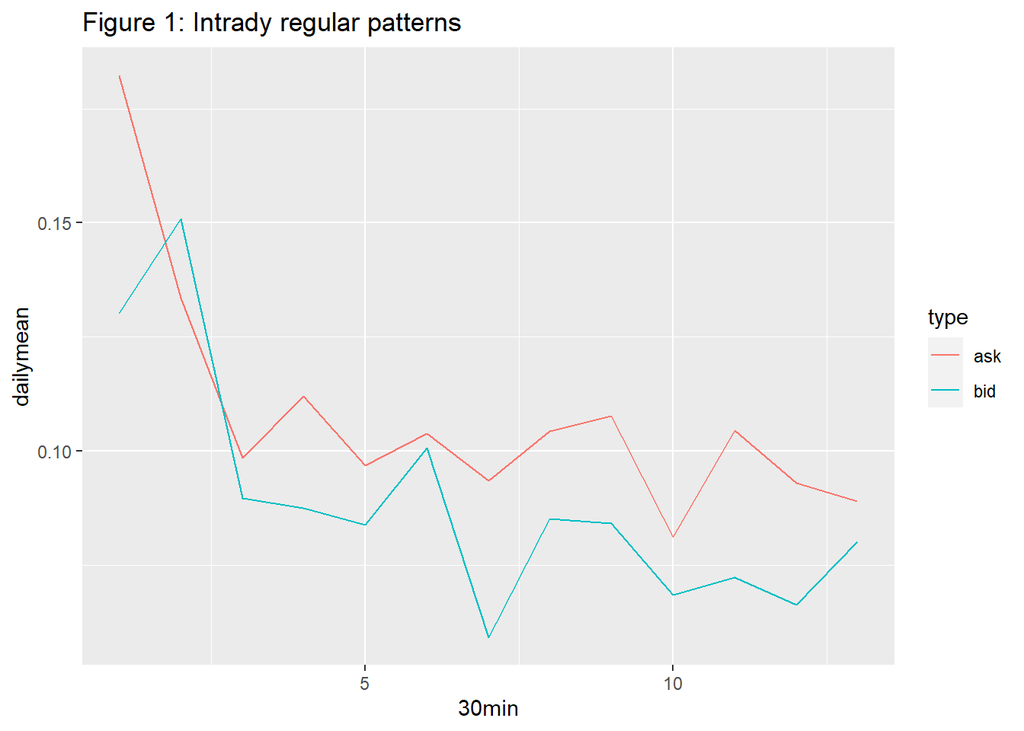

```r
min30<-c()
for (i in 1:13){
  min30<-c(min30,rep(i,30))
}

ask.h.overall <- Stock1LOBLEV[sign<0,.(ask.h.overall = sum(hidden)/(sum(displayed)+sum(hidden))), by="time"] #ask overall
ask.h.overall<-cbind(ask.h.overall,"30min"=min30[1:length(ask.h.overall$time)])
ask.h.overall<-ask.h.overall[,.(dailymean = mean(ask.h.overall)), by="30min"]

ask.h.at <- Stock1LOBLEV[sign==-1,.(ask.h.at = sum(hidden)/(sum(displayed)+sum(hidden))), by="time"] #ask at
ask.h.at<-cbind(ask.h.at,"30min"=min30[1:length(ask.h.at$time)])
ask.h.at<-ask.h.at[,.(dailymean = mean(ask.h.at)), by="30min"]

ask.h.near <- Stock1LOBLEV[sign<=-2 & sign >=-5,.(ask.h.near = sum(hidden)/(sum(displayed)+sum(hidden))), by="time"] #ask near
ask.h.near<-cbind(ask.h.near,"30min"=min30[1:length(ask.h.near$time)])
ask.h.near<-ask.h.near[,.(dailymean = mean(ask.h.near)), by="30min"]

ask.h.behind <- Stock1LOBLEV[sign<=-6,.(ask.h.behind = sum(hidden)/(sum(displayed)+sum(hidden))), by="time"] #ask behind
ask.h.behind<-cbind(ask.h.behind,"30min"=min30[1:length(ask.h.behind$time)])
ask.h.behind<-ask.h.behind[,.(dailymean = mean(ask.h.behind)), by="30min"]

bid.h.overall <- Stock1LOBLEV[sign>0,.(bid.h.overall = sum(hidden)/(sum(displayed)+sum(hidden))), by="time"] #bid overall
bid.h.overall<-cbind(bid.h.overall,"30min"=min30[1:length(bid.h.overall$time)])
bid.h.overall<-bid.h.overall[,.(dailymean = mean(bid.h.overall)), by="30min"]

bid.h.at <- Stock1LOBLEV[sign==1,.(bid.h.at = sum(hidden)/(sum(displayed)+sum(hidden))), by="time"] #bid at
bid.h.at<-cbind(bid.h.at,"30min"=min30[1:length(bid.h.at$time)])
bid.h.at<-bid.h.at[,.(dailymean = mean(bid.h.at)), by="30min"]

bid.h.near <- Stock1LOBLEV[sign>=2 & sign <=5,.(bid.h.near = sum(hidden)/(sum(displayed)+sum(hidden))), by="time"] #bid near
bid.h.near<-cbind(bid.h.near,"30min"=min30[1:length(bid.h.near$time)])
bid.h.near<-bid.h.near[,.(dailymean = mean(bid.h.near)), by="30min"]

bid.h.behind <- Stock1LOBLEV[sign>=6,.(bid.h.behind = sum(hidden)/(sum(displayed)+sum(hidden))), by="time"] #bid behind
bid.h.behind<-cbind(bid.h.behind,"30min"=min30[1:length(bid.h.behind$time)])
bid.h.behind<-bid.h.behind[,.(dailymean = mean(bid.h.behind)), by="30min"]

overall <- rbind(cbind(ask.h.overall,type="ask"),cbind(bid.h.overall,type="bid"))
ggplot(overall,aes(`30min`,dailymean, color=type))+
  geom_line()+
  ggtitle("Figure 1: Intrady regular patterns")
```

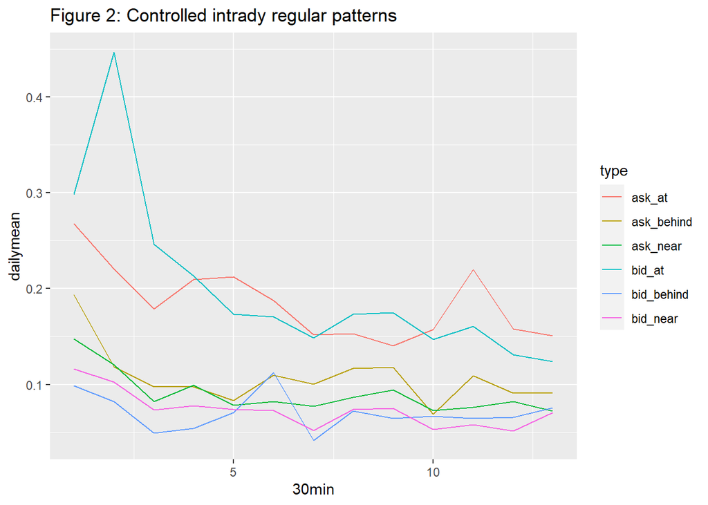

```r
control <- rbind(cbind(ask.h.at,type="ask_at"),cbind(bid.h.at,type="bid_at"),
                  cbind(ask.h.near,type="ask_near"),cbind(bid.h.near,type="bid_near"),
                  cbind(ask.h.behind,type="ask_behind"),cbind(bid.h.behind,type="bid_behind"))
ggplot(control,aes(`30min`,dailymean, color=type))+
  geom_line()+
  ggtitle("Figure 2: Controlled intrady regular patterns")
```